# Week 1 lab 3

Henry He

2020/7/30

# States data set

Below we construct a data frame, of 50 states x 10 variables. The first 8 variables are numeric and the last 2 are factors. The numeric variables here come from the built-in `state.x77` matrix, which records various demographic factors on 50 US states, measured in the 1970s. You can learn more about this state data set by typing `?state.x77` into your R console.

```r
state.df = data.frame(state.x77, Region=state.region, Division=state.division)
```

# Basic data frame manipulations

- **1a.** Add a column to `state.df`, containing the state abbreviations that are stored in the built-in vector `state.abb`. Name this column `Abbr`. You can do this in (at least) two ways: by using a call to `data.frame()`, or by directly defining `state.df$Abbr`. Display the first 3 rows and all 11 columns of the new `state.df`.

```r
state.df$Abbr <- state.abb
state.df[1:3,]
```

```
##         Population Income Illiteracy Life.Exp Murder HS.Grad Frost   Area Region           Division Abbr
## Alabama       3615   3624        2.1    69.05   15.1    41.3    20  50708  South East South Central   AL
## Alaska         365   6315        1.5    69.31   11.3    66.7   152 566432   West            Pacific   AK
## Arizona       2212   4530        1.8    70.55    7.8    58.1    15 113417   West           Mountain   AZ
```

- **1b.** Remove the `Region` column from `state.df`. You can do this in (at least) two ways: by using negative indexing, or by directly setting `state.df$Region` to be `NULL`. Display the first 3 rows and all 10 columns of `state.df`.

```r
state.df$Region <- NULL
state.df[1:3,]
```

```
##         Population Income Illiteracy Life.Exp Murder HS.Grad Frost   Area           Division Abbr
## Alabama       3615   3624        2.1    69.05   15.1    41.3    20  50708 East South Central   AL
## Alaska         365   6315        1.5    69.31   11.3    66.7   152 566432            Pacific   AK
## Arizona       2212   4530        1.8    70.55    7.8    58.1    15 113417           Mountain   AZ
```

- **1c.** Add two columns to `state.df`, containing the x and y coordinates (longitude and latitude, respectively) of the center of the states, that are stored in the (existing) list `state.center`. Hint: take a look at this list in the console, to see what its elements are named. Name these two columns `Center.x` and `Center.y`. Display the first 3 rows and all 12 columns of `state.df`.

```r
# x
x <- c(state.center[[1]])
state.df$Center.X <- x
y <- c(state.center[[2]])
state.df$Center.Y <- y
state.df[1:3,]
```

```
##         Population Income Illiteracy Life.Exp Murder HS.Grad Frost   Area           Division Abbr  Center.X Center.Y
## Alabama       3615   3624        2.1    69.05   15.1    41.3    20  50708 East South Central   AL  -86.7509  32.5901
## Alaska         365   6315        1.5    69.31   11.3    66.7   152 566432            Pacific   AK -127.2500  49.2500
## Arizona       2212   4530        1.8    70.55    7.8    58.1    15 113417           Mountain   AZ -111.6250  34.2192
```

- **1d.** Make a new data frame which contains only those states whose longitude is less than -100. Do this in two different ways: using manual indexing, and `subset`(). Check that they are equal to each other, using an appropriate function call.

```r
new_df_1 <- state.df[state.df$Center.X < -100,]


new_df_2 <- subset(state.df , state.df$Center.X < -100)

all.equal(new_df_1,new_df_2)
```

```
## [1] TRUE
```

- **1e.** Make a new data frame which contains only the states whose longitude is less than -100, and whose murder rate is above 9%. Print this new data frame to the console. Among the states in this new data frame, which has the highest average life expectancy?

```r
state.df[(state.df$Center.X < -100)& state.df$Murder > 9,]
```

```
##            Population Income Illiteracy Life.Exp Murder HS.Grad Frost   Area Division Abbr Center.X Center.Y
## Alaska            365   6315        1.5    69.31   11.3    66.7   152 566432  Pacific   AK -127.250  49.2500
## California      21198   5114        1.1    71.71   10.3    62.6    20 156361  Pacific   CA -119.773  36.5341
## Nevada            590   5149        0.5    69.03   11.5    65.2   188 109889 Mountain   NV -116.851  39.1063
## New Mexico       1144   3601        2.2    70.32    9.7    55.2   120 121412 Mountain   NM -105.942  34.4764
```

```r
state.df[which.max(state.df$Life.Exp),]
```

```
##        Population Income Illiteracy Life.Exp Murder HS.Grad Frost Area Division Abbr Center.X Center.Y
## Hawaii        868   4963        1.9     73.6    6.2    61.9     0 6425  Pacific   HI  -126.25    31.75
```

# Prostate cancer data set

Let’s return to the prostate cancer data set that we looked in Week 2 (taken from the book The Elements of Statistical Learning). Below we read in a data frame of 97 men x 9 variables. You can remind yourself about what’s been measured by looking back at the lab/homework (or by visiting the URL linked above in your web browser, clicking on “Data” on the left-hand menu, and clicking “Info” under “Prostate”).

```r
pros.dat =
  read.table("http://www.stat.cmu.edu/~ryantibs/statcomp/data/pros.dat")
```

# Practice with the apply family

- **2a.** Using `sapply()`, calculate the mean of each variable. Also, calculate the standard deviation of each variable. Each should require just one line of code. Display your results.

```r
sapply(pros.dat, FUN = mean)
```

```
##     lcavol    lweight        age       lbph        svi        lcp    gleason      pgg45       lpsa
##  1.3500096  3.6289427 63.8659794  0.1003556  0.2164948 -0.1793656  6.7525773 24.3814433  2.4783869
```

```r
sapply(pros.dat,FUN = sd)
```

```
##     lcavol    lweight        age       lbph        svi        lcp    gleason      pgg45       lpsa
##  1.1786249  0.4284112  7.4451171  1.4508066  0.4139949  1.3982496  0.7221341 28.2040346  1.1543291
```

- **2b.** Let's plot each variable against SVI. Using `lapply()`, plot each column, excluding SVI, on the y-axis with SVI on the x-axis. This should require just one line of code. **Challenge**: label the y-axes in your plots appropriately. Your solution should still consist of just one line of code and use an apply function. Hint: for this part, consider using `mapply()`.

```r
pros.dat[colnames(pros.dat) != "svi"]
```

```
##          lcavol  lweight age        lbph         lcp gleason pgg45       lpsa
## 1  -0.579818495 2.769459  50 -1.38629436 -1.38629436       6     0 -0.4307829
## 2  -0.994252273 3.319626  58 -1.38629436 -1.38629436       6     0 -0.1625189
## 3  -0.510825624 2.691243  74 -1.38629436 -1.38629436       7    20 -0.1625189
## 4  -1.203972804 3.282789  58 -1.38629436 -1.38629436       6     0 -0.1625189
## 5   0.751416089 3.432373  62 -1.38629436 -1.38629436       6     0  0.3715636
## 6  -1.049822124 3.228826  50 -1.38629436 -1.38629436       6     0  0.7654678
## 7   0.737164066 3.473518  64  0.61518564 -1.38629436       6     0  0.7654678
## 8   0.693147181 3.539509  58  1.53686722 -1.38629436       6     0  0.8544153
## 9  -0.776528789 3.539509  47 -1.38629436 -1.38629436       6     0  1.0473190
## 10  0.223143551 3.244544  63 -1.38629436 -1.38629436       6     0  1.0473190
## 11  0.254642218 3.604138  65 -1.38629436 -1.38629436       6     0  1.2669476
## 12 -1.347073648 3.598681  63  1.26694760 -1.38629436       6     0  1.2669476
## 13  1.613429934 3.022861  63 -1.38629436 -0.59783700       7    30  1.2669476
## 14  1.477048724 2.998229  67 -1.38629436 -1.38629436       7     5  1.3480731
```

[output cut: 83 more lines]

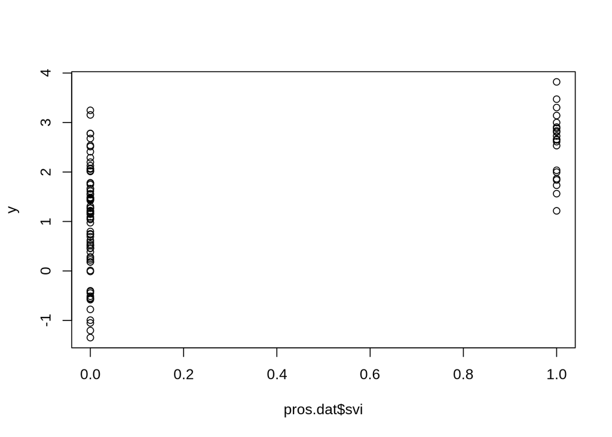

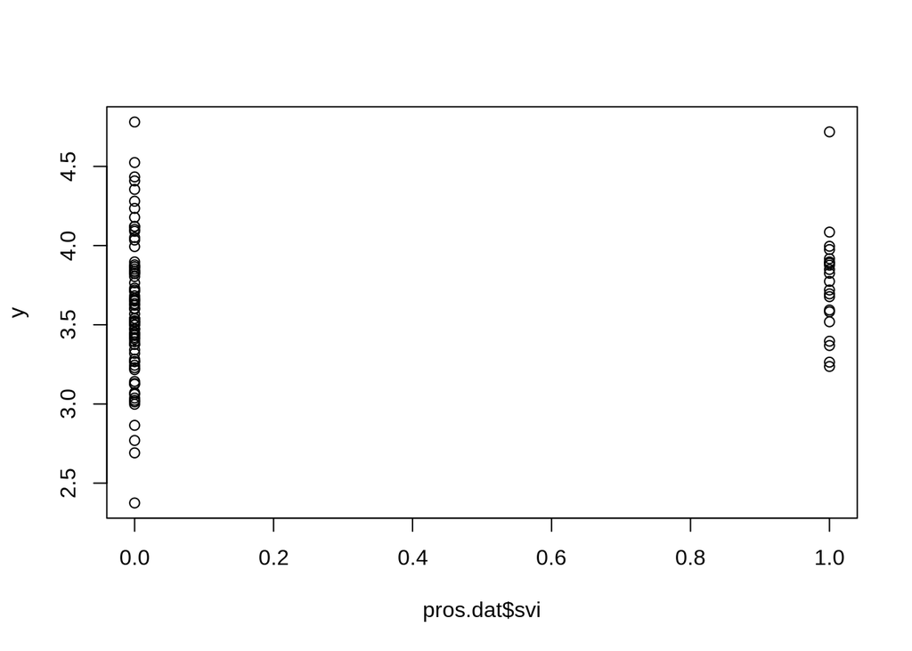

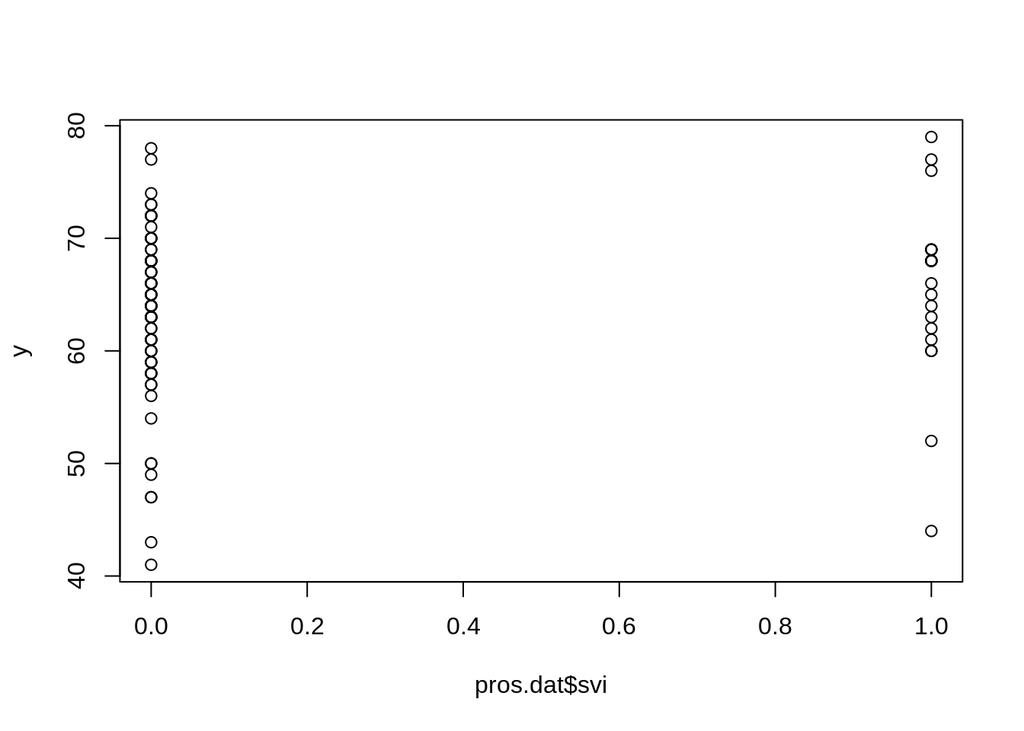

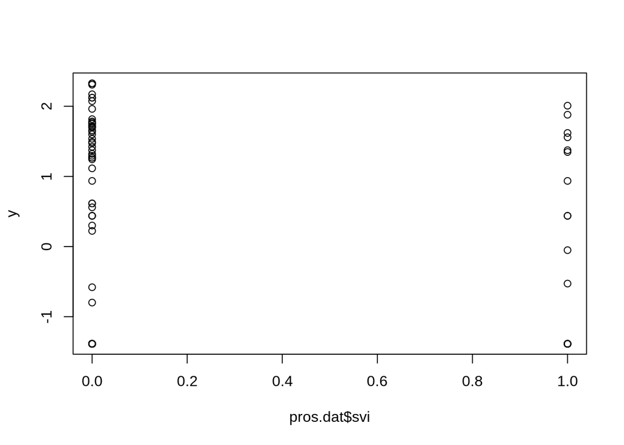

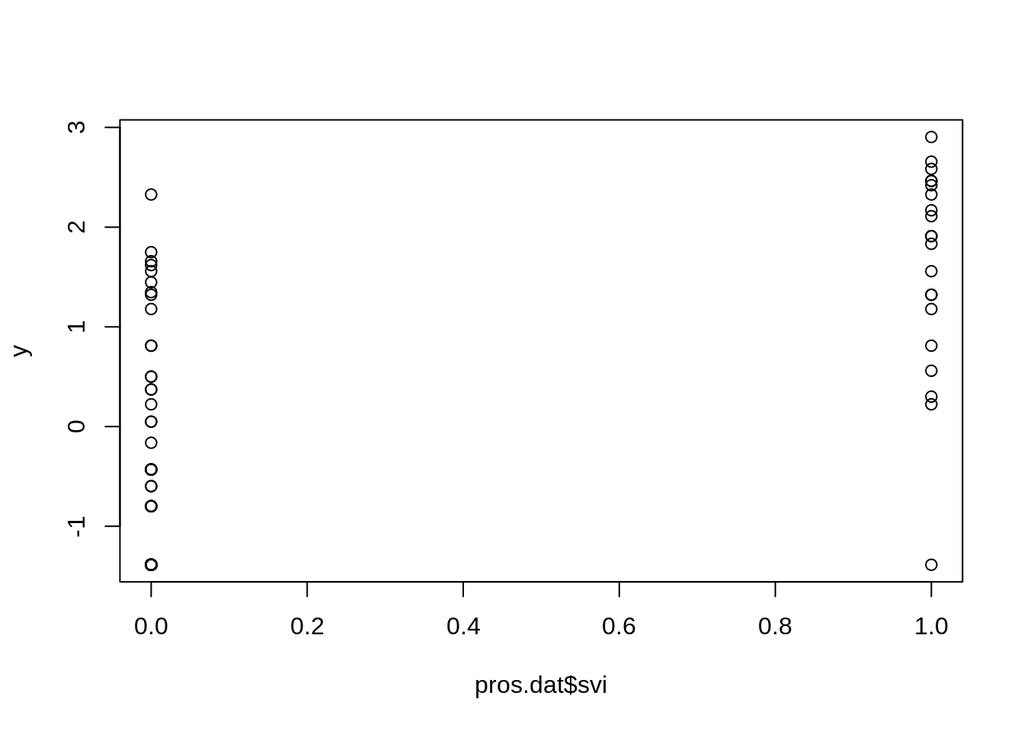

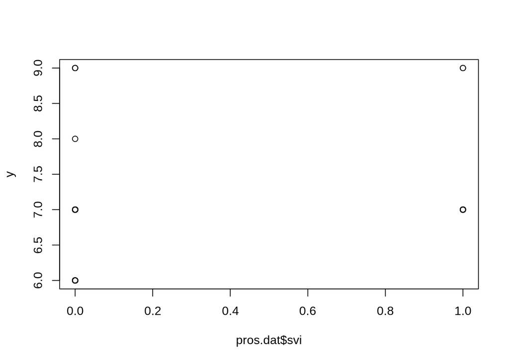

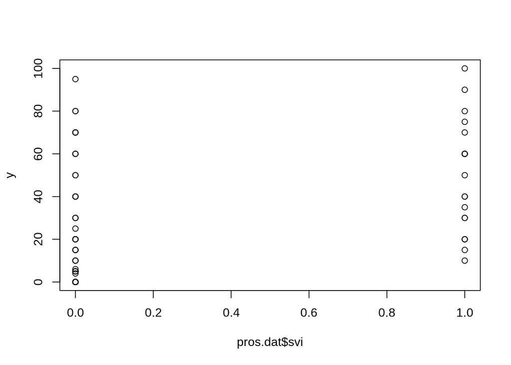

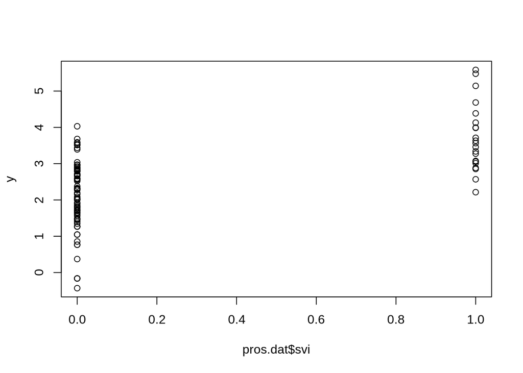

```r
lapply(pros.dat[colnames(pros.dat) != "svi"], function(y){
  plot(y = y ,x = pros.dat$svi)
} )
```

- **2c.** Now, use `lapply()` to perform t-tests for each variable in the data set, between SVI and non-SVI groups. To be precise, you will perform a t-test for each variable excluding the SVI variable itself. For convenience, we've defined a function `t.test.by.ind()` below, which takes a numeric variable `x`, and then an indicator variable `ind` (of 0s and 1s) that defines the groups. Run this function on the columns of `pros.dat`, excluding the SVI column itself, and save the result as `tests`. What kind of data structure is `tests`? Print it to the console.

```r
t.test.by.ind = function(x, ind) {
  stopifnot(all(ind %in% c(0, 1)))
  return(t.test(x[ind == 0], x[ind == 1]))
}
tests <- lapply(pros.dat[colnames(pros.dat) != "svi"],colnames(pros.dat) != "svi", FUN = t.test.by.ind)
class(tests)
```

```
## [1] "list"
```

**2d.** Using `lapply()` again, extract the p-values from the `tests` object you created in the last question, with just a single line of code. Hint: first, take a look at the first element of `tests`, what kind of object is it, and how is the p-value stored? Second, run the command `"[["(pros.dat, "lcavol")` in your console---what does this do? Now use what you've learned to extract p-values from the `tests` object

```r
lapply(tests, function(x){x$p.value})
```

```
## $lcavol
## [1] 0.9616501
##
## $lweight
## [1] 0.9890955
##
## $age
## [1] 0.6097865
##
## $lbph
## [1] 0.8591427
##
## $lcp
## [1] 0.6316527
##
## $gleason
## [1] 0.7919998
##
## $pgg45
## [1] 0.8050196
##
## $lpsa
## [1] 0.8056656
```

# Rio Olympics data set

Now we're going to examine data from the 2016 Summer Olympics in Rio de Janeiro, taken from https://github.com/flother/rio2016 (itself put together by scraping the official Summer Olympics website for information about the athletes). Below we read in the data and store it as `rio`.

```r
rio = read.csv("http://www.stat.cmu.edu/~ryantibs/statcomp/data/rio.csv")
## filedir = file.choose()
## rio = read.csv(filedir)
```

# More practice with data frames and apply

- **3a.** What kind of object is rio? What are its dimensions and columns names of `rio`? What does each row represent? Is there any missing data?

```r
class(rio)
```

```
## [1] "data.frame"
```

```r
dim(rio)
```

```
## [1] 11538    12
```

```r
colnames(rio)
```

```
##  [1] "id"            "name"          "nationality"   "sex"           "date_of_birth" "height"        "weight"
##  [8] "sport"         "gold"          "silver"        "bronze"        "info"
```

```r
summary(rio)
```

```
##        id                        name        nationality       sex          date_of_birth       height          weight
##  Min.   :    18347   Ahmed Mohamed :    2   USA    : 567   female:5205   1988-03-05:    9   Min.   :1.210   Min.   : 31.00
##  1st Qu.:245099667   Ben Saxton    :    2   BRA    : 485   male  :6333   1990-12-20:    9   1st Qu.:1.690   1st Qu.: 60.00
##  Median :500201062   Carli Lloyd   :    2   GER    : 441                 1993-02-18:    9   Median :1.760   Median : 70.00
##  Mean   :499988509   Daniel Vargas :    2   AUS    : 431                 1988-04-03:    8   Mean   :1.766   Mean   : 72.07
##  3rd Qu.:753987424   David Graf    :    2   FRA    : 410                 1988-04-29:    8   3rd Qu.:1.840   3rd Qu.: 81.00
##  Max.   :999987786   Felipe Aguilar:    2   CHN    : 404                 1989-03-01:    8   Max.   :2.210   Max.   :170.00
##                      (Other)       :11526   (Other):8800                 (Other)   :11487   NA's   :330     NA's   :659
##        sport           gold             silver            bronze
##  athletics:2363   Min.   :0.00000   Min.   :0.00000   Min.   :0.00000
##  aquatics :1445   1st Qu.:0.00000   1st Qu.:0.00000   1st Qu.:0.00000
##  football : 611   Median :0.00000   Median :0.00000   Median :0.00000
##  rowing   : 547   Mean   :0.05772   Mean   :0.05677   Mean   :0.06102
##  cycling  : 525   3rd Qu.:0.00000   3rd Qu.:0.00000   3rd Qu.:0.00000
##  hockey   : 432   Max.   :5.00000   Max.   :2.00000   Max.   :2.00000
##  (Other)  :5615
##                                                                                                                                                                                                                                        info
##                                                                                                                                                                                                                                          :11407
##  A collector of medals for Great Britain in equestrian eventing, William Fox-Pit won the silver at Athens 2004 and London 2012, and a bronze at Beijing 2008. He was his country's first athlete to achieve the world number one ranking.:    1
##  A fundamental player in the gold medal-winning Brazilian team at Beijing 2008 and London 2012, opposite spiker Sheilla holds seven Grand Prix titles (the most recent from July 2016) and two world championship silvers.               :    1
##  A holder of nine world titles, sprinter Allyson Felix has won four golds and two silvers from the last three Olympic Games, since Athens 2004. At London 2012, she took gold in the 200m and 4x100m and 4x400m relays.                  :    1
##  A holder of seven world and 10 World Cup titles, Elisa di Francisca left London 2012 with two fencing gold medals. She won the individual foil event and was part of the victorious Italian team.                                       :    1
##  A holder of two bronze medals, won at Beijing 2008 and London 2012, Serbia's Filip Filipović was world champion at Kazan 2015 and Rome 2009, and won five European championships, including the 2016 edition.                           :    1
##  (Other)                                                                                                                                                                                                                                 :  126
```

- **3b.** Use `rio` to answer the following questions. How many athletes competed in the 2016 Summer Olympics? How many countries were represented? What were these countries, and how many athletes competed for each one? Which country brought the most athletes, and how many was this? Hint: for a factor variable `f`, you can use `table(f)` see how many elements in `f` are in each level of the factor.

```r
length(rio$name)
```

```
## [1] 11538
```

```r
t <- table(rio$nationality)
length(table(rio$nationality))
```

```
## [1] 207
```

```r
t[which(t == max(t))]
```

```
## USA
## 567
```

- **3c.** How many medals of each type---gold, silver, bronze---were awarded at this Olympics? Are they equal? Is this result surprising, and can you explain what you are seeing?

```r
sum(rio$bronze)
```

```
## [1] 704
```

```r
sum(rio$silver)
```

```
## [1] 655
```

```r
sum(rio$gold)
```

```
## [1] 666
```

- **3d.** Create a column called `total` which adds the number of gold, silver, and bronze medals for each athlete, and add this column to `rio`. Which athlete had the most number of medals and how many was this? Gold medals? Silver medals? In the case of ties, here, display all the relevant athletes.

```r
rio$total <- rio$gold + rio$silver + rio$bronze
rio[which(rio$total == max(rio$total)),c(2,13)]
```

```
##                name total
## 7402 Michael Phelps     6
```

```r
rio[which(rio$gold == max(rio$gold)),c(2,9)]
```

```
##                name gold
## 7402 Michael Phelps    5
```

```r
rio[which(rio$silver == max(rio$silver)),c(2,10)]
```

```
##                              name silver
## 419             Alexandra Raisman      2
## 1880    Chad Guy Bertrand le Clos      2
## 2301                 Danell Leyva      2
## 2544               Denis Abliazin      2
## 2749                 Duncan Scott      2
## 3049                  Emma McKeon      2
## 3441             Florent Manaudou      2
## 3512              Franziska Weber      2
## 4419  Isaquias Queiroz dos Santos      2
## 4578                    James Guy      2
## 4713                  Jazz Carlin      2
## 6524              Madeline Groves      2
## 6828                 Maria Paseka      2
## 8922                Rebecca James      2
## 9534                 Sarah Hammer      2
## 9903                Simone Manuel      2
## 10297           Taoufik Makhloufi      2
## 10523                 Tina Dietze      2
## 10986                  Wenyan Sun      2
## 11102               Xuechen Huang      2
## 11371               Yulia Efimova      2
```

```r
rio[which(rio$bronze == max(rio$bronze)),c(2,11)]
```

```
##                      name bronze
## 747       Andre de Grasse      2
## 1715       Cameron McEvoy      2
## 3555       Gabriele Detti      2
## 5911        Kyle Chalmers      2
## 5986  Lasse Norman Hansen      2
## 7285     Meaghan Benfeito      2
## 7937        Nathan Adrian      2
## 8594       Penny Oleksiak      2
## 9053        Risako Mitsui      2
## 10339 Taylor Madison Ruck      2
## 11366         Yukiko Inui      2
```

- **3e.** Using `tapply()`, calculate the total medal count for each country. Save the result as `total.by.nat`, and print it to the console. Which country had the most number of medals, and how many was this? How many countries had zero medals?

```r
total.by.nat <- tapply(rio$total,INDEX = rio$nationality,sum)
total.by.nat
```

```
## AFG ALB ALG AND ANG ANT ARG ARM ARU ASA AUS AUT AZE BAH BAN BAR BDI BEL BEN BER BHU BIH BIZ BLR BOL BOT BRA BRN BRU BUL BUR CAF
##   0   0   2   0   0   0  22   4   0   0  82   2  18   6   0   0   1  21   0   0   0   0   0  12   0   0  51   2   0   7   0   0
## CAM CAN CAY CGO CHA CHI CHN CIV CMR COD COK COL COM CPV CRC CRO CUB CYP CZE DEN DJI DMA DOM ECU EGY ERI ESA ESP EST ETH FIJ FIN
##   0  69   0   0   0   0 113   2   0   0   0   8   0   0   0  24  11   0  15  41   0   0   1   0   3   0   0  45   4   8  13   1
## FRA FSM GAB GAM GBR GBS GEO GEQ GER GHA GRE GRN GUA GUI GUM GUY HAI HKG HON HUN INA IND IOA IRI IRL IRQ ISL ISR ISV ITA IVB JAM
##  95   0   0   0 145   0   7   0 160   0   7   1   0   0   0   0   0   0   0  22   4   2   2   8   3   0   0   2   0  72   0  30
## JOR JPN KAZ KEN KGZ KIR KOR KOS KSA LAO LAT LBA LBR LCA LES LIB LIE LTU LUX MAD MAR MAS MAW MDA MDV MEX MGL MHL MKD MLI MLT MNE
##   1  65  17  13   0   0  26   1   0   0   0   0   0   0   0   0   0   7   0   0   1   8   0   1   0   5   2   0   0   0   0   0
## MON MOZ MRI MTN MYA NAM NCA NED NEP NGR NIG NOR NRU NZL OMA PAK PAN PAR PER PHI PLE PLW PNG POL POR PRK PUR QAT ROT ROU RSA RUS
##   0   0   0   0   0   0   0  47   0  18   1  19   0  36   0   0   0   0   0   1   0   0   0  16   1   7   1   1   0  17  23 115
## RWA SAM SEN SEY SIN SKN SLE SLO SMR SOL SOM SRB SRI SSD STP SUD SUI SUR SVK SWE SWZ SYR TAN TGA THA TJK TKM TLS TOG TPE TTO TUN
##   0   0   0   0   1   0   0   4   0   0   0  53   0   0   0   0  11   0   8  28   0   0   0   0   6   1   0   0   0   5   1   3
## TUR TUV UAE UGA UKR URU USA UZB VAN VEN VIE VIN YEM ZAM ZIM
##   8   0   1   0  15   0 264  13   0   3   2   0   0   0   0
```

```r
length(total.by.nat[total.by.nat == 0])
```

```
## [1] 120
```

- **3f.** Among the countries that had zero medals, which had the most athletes, and how many athletes was this? (Ouch!)

```r
t <- table(rio$nationality)
t[total.by.nat == 0]
```

```
##
## AFG ALB AND ANG ANT ARU ASA BAN BAR BEN BER BHU BIH BIZ BOL BOT BRU BUR CAF CAM CAY CGO CHA CHI CMR COD COK COM CPV CRC CYP DJI
##   3   6   5  26   9   7   4   7  11   6   8   2  11   3  12  12   3   5   6   6   5  10   2  42  24   4   9   4   5  11  16   7
## DMA ECU ERI ESA FSM GAB GAM GBS GEQ GHA GUA GUI GUM GUY HAI HKG HON IRQ ISL ISV IVB KGZ KIR KSA LAO LAT LBA LBR LCA LES LIB LIE
##   2  38  12   8   5   6   4   5   2  16  21   5   5   6  10  38  30  26   8   7   4  19   3  11   6  32   7   2   5   8   9   3
## LUX MAD MAW MDV MHL MKD MLI MLT MNE MON MOZ MRI MTN MYA NAM NCA NEP NRU OMA PAK PAN PAR PER PLE PLW PNG ROT RWA SAM SEN SEY SKN
##  10   6   5   4   5   6   6   7  35   3   6  11   2   7  10   5   7   2   4   7  10  11  29   6   5   8  10   7   8  22  10   7
## SLE SMR SOL SOM SRI SSD STP SUD SUR SWZ SYR TAN TGA TKM TLS TOG TUV UGA URU VAN VIN YEM ZAM ZIM
##   4   5   3   2   9   3   3   6   6   2   7   7   7   9   3   5   1  21  17   4   4   3   7  35
```

```r
m <- max(t[total.by.nat == 0])
t[total.by.nat == 0][which(t[total.by.nat == 0] == m)]
```

```
## CHI
##  42
```

# Young and old folks

- **4a.** The variable `date_of_birth` contains strings of the date of birth of each athlete. Use the `substr()` function to extract the year of birth for each athlete, and then create a new numeric variable called `age`, equal to 2016 - (the year of birth). (Here we're ignoring days and months for simplicity.) Hint: to extract the first 4 characters of a string `str`, you can use `substr(str, 1, 4)`. As always, you can also look at the help file for `substr()` for more details.

Add the `age` variable to the `rio` data frame. variable Who is the oldest athlete, and how old is he/she? Youngest athlete, and how old is he/she? In the case of ties, here, display all the relevant athletes.

```r
age <- 2016 - as.numeric(substr(rio$date_of_birth,1,4))
rio$age <- age
rio[which(rio$age == max(rio$age)),c(2,14)]
```

```
##                name age
## 5300 Julie Brougham  62
## 7093     Mary Hanna  62
```

```r
rio[which(rio$age == min(rio$age)),c(2,14)]
```

```
##                       name age
## 655       Ana Iulia Dascal  14
## 2432       Darya Semyonova  14
## 3306     Fatima Alkaramova  14
## 3599         Gaurika Singh  14
## 5577     Kaya Adwoa Forson  14
## 9919  Siri Arun Budcharern  14
## 10434          Thint Myaat  14
## 11149            Yanhan Ai  14
```

- **4b.** Answer the same questions as in the last part, but now only among athletes who won a medal.

```r
medal <- rio[which(rio$gold > 0),]
medal[which(medal$age == max(medal$age)),c(2,14)]
```

```
##              name age
## 8019 Nick Skelton  59
```

```r
medal[which(medal$age == min(medal$age)),c(2,14)]
```

```
##          name age
## 8774 Qian Ren  15
```

- **4c.** Using a single call to `tapply()`, answer: how old are the youngest and oldest athletes, for each sport?

```r
young <- tapply(rio$age,INDEX = rio$sport,min)
young
```

```
##          aquatics           archery         athletics         badminton        basketball            boxing             canoe
##                14                17                16                19                20                18                18
##           cycling        equestrian           fencing          football              golf        gymnastics          handball
##                18                18                16                16                18                16                19
##            hockey              judo modern pentathlon            rowing      rugby sevens           sailing          shooting
##                18                19                17                18                18                17                16
##      table tennis         taekwondo            tennis         triathlon        volleyball     weightlifting         wrestling
##                15                17                19                19                18                16                18
```

```r
old <- tapply(rio$age,INDEX = rio$sport,max)
old
```

```
##          aquatics           archery         athletics         badminton        basketball            boxing             canoe
##                41                44                47                40                39                37                49
##           cycling        equestrian           fencing          football              golf        gymnastics          handball
##                45                62                42                41                47                41                44
##            hockey              judo modern pentathlon            rowing      rugby sevens           sailing          shooting
##                37                39                37                57                36                55                56
##      table tennis         taekwondo            tennis         triathlon        volleyball     weightlifting         wrestling
##                54                38                44                38                41                41                38
```

- **4d.** You should see that your output from `tapply()` in the last part is a list, which is not particularly convenient. Convert this list into a matrix that has one row for each sport, and two columns that display the ages of the youngest and oldest athletes in that sport. The first 3 rows should look like this:

  ```
                Youngest Oldest
  aquatics               14     41
  archery                17     44
  athletics              16     47
  ```

  You'll notice that we set the row names according to the sports, and we also set appropriate column names. Hint: `unlist()` will unravel all the values in a list; and `matrix()`, as you've seen before, can be used to create a matrix from a vector of values. After you've converted the results to a matrix, print it to the console (and make sure its first 3 rows match those displayed above).

```r
m <- as.matrix(unlist(young))
m <- cbind(m,old)
colnames(m) <- c("Yougest","Oldest")
m
```

```
##                   Yougest Oldest
## aquatics               14     41
## archery                17     44
## athletics              16     47
## badminton              19     40
## basketball             20     39
## boxing                 18     37
## canoe                  18     49
## cycling                18     45
## equestrian             18     62
## fencing                16     42
## football               16     41
## golf                   18     47
## gymnastics             16     41
## handball               19     44
## hockey                 18     37
## judo                   19     39
## modern pentathlon      17     37
## rowing                 18     57
## rugby sevens           18     36
## sailing                17     55
## shooting               16     56
## table tennis           15     54
## taekwondo              17     38
## tennis                 19     44
## triathlon              19     38
## volleyball             18     41
## weightlifting          16     41
## wrestling              18     38
```

# Sport by sport

- **5a.** Create a new data frame called `sports`, which we'll populate with information about each sporting event at the Summer Olympics. Initially, define `sports` to contain a single variable called `sport` which contains the names of the sporting events in alphabetical order. Then, add a column called `n_participants` which contains the number of participants in each sport. Use one of the apply functions to determine the number of gold medals given out for each sport, and add this as a column called `n_gold`. Using your newly created `sports` data frame, calculate the ratio of the number of gold medals to participants for each sport. Which sport has the highest ratio? Which has the lowest?

```r
sports <- data.frame(table(rio$sport))
colnames(sports) <- c("sports","n_participants")
sum_gold = function(x){
  sum(rio$gold[rio$sport == x])
}
sports$n_gold <- c(apply(sports[1],MARGIN = 1,sum_gold))
sports$ratio <- sports$n_gold/sports$n_participants
sports[which(sports$ratio == max(sports$ratio)),]
```

```
##        sports n_participants n_gold      ratio
## 13 gymnastics            324     30 0.09259259
```

```r
sports[which(sports$ratio == min(sports$ratio)),]
```

```
##    sports n_participants n_gold      ratio
## 12   golf            120      2 0.01666667
```

- **5b.** Use one of the apply functions to compute the average weight of the participants in each sport, and add this as a column to `sports` called `ave_weight`. Important: there are missing weights in the data set coded as `NA`, but your column `ave_weight` should ignore these, i.e., it should be itself free of `NA` values. You will have to pass an additional argument to your apply call in order to achieve this. Hint: look at the help file for the `mean()` function; what argument can you set to ignore `NA` values? Once computed, display the average weights along with corresponding sport names, in decreasing order of average weight.

```r
avg_weight = function(x){
    mean(rio$weight[rio$sport == x],na.rm = TRUE)
}
sports$avg_weight <- c(apply(sports[1],MARGIN = 1, avg_weight))
sports
```

```
##               sports n_participants n_gold      ratio avg_weight
## 1           aquatics           1445    120 0.08304498   72.30164
## 2            archery            128      8 0.06250000   72.19048
## 3          athletics           2363     66 0.02793060   67.71773
## 4          badminton            172      8 0.04651163   68.77439
## 5         basketball            288     24 0.08333333   87.75000
## 6             boxing            286     13 0.04545455        NaN
## 7              canoe            331     27 0.08157100   77.01529
## 8            cycling            525     27 0.05142857   67.82072
## 9         equestrian            222     15 0.06756757   67.49302
## 10           fencing            246     21 0.08536585   70.66122
## 11          football            611     36 0.05891980   68.43396
## 12              golf            120      2 0.01666667   71.44348
## 13        gymnastics            324     30 0.09259259   54.27900
## 14          handball            363     29 0.07988981   83.71060
## 15            hockey            432     34 0.07870370   68.90046
## 16              judo            392     14 0.03571429   76.87632
## 17 modern pentathlon             72      2 0.02777778   65.95833
## 18            rowing            547     48 0.08775137   79.93832
## 19      rugby sevens            300     25 0.08333333   78.72391
## 20           sailing            380     15 0.03947368   71.16935
## 21          shooting            390     15 0.03846154   73.90526
## 22      table tennis            172      8 0.04651163   65.17751
## 23         taekwondo            128      8 0.06250000   68.08800
## 24            tennis            196      8 0.04081633   73.16230
## 25         triathlon            110      2 0.01818182   60.63303
## 26        volleyball            384     28 0.07291667   80.10209
## 27     weightlifting            258     15 0.05813953   79.98062
## 28         wrestling            353     18 0.05099150   77.74212
```

- **5c.** As in the last part, compute the average weight of atheletes in each sport, but now separately for men and women. You should therefore add two new columns, called `ave_weight_men` and `ave_weight_women`, to `sports`. Once computed, display the average weights along with corresponding sports, for men and women, each list sorted in decreasing order of average weight. Are the orderings roughly similar

```r
avg_weight_sex = function(x,s){
    mean(rio$weight[rio$sport == x & rio$sex == s],na.rm = TRUE)
}
sports$avg_weight_men <- c(apply(sports[1],MARGIN = 1, FUN = avg_weight_sex,s = "male"))
sports$avg_weight_women <- c(apply(sports[1],MARGIN = 1, FUN = avg_weight_sex,s = "female"))
sports
```

```
##               sports n_participants n_gold      ratio avg_weight avg_weight_men avg_weight_women
## 1           aquatics           1445    120 0.08304498   72.30164       82.21906         62.28448
## 2            archery            128      8 0.06250000   72.19048       80.07937         64.30159
## 3          athletics           2363     66 0.02793060   67.71773       74.77768         60.15254
## 4          badminton            172      8 0.04651163   68.77439       76.15663         61.20988
## 5         basketball            288     24 0.08333333   87.75000      100.29787         75.37762
## 6             boxing            286     13 0.04545455        NaN            NaN              NaN
## 7              canoe            331     27 0.08157100   77.01529       82.15000         66.45794
## 8            cycling            525     27 0.05142857   67.82072       72.57605         60.20725
## 9         equestrian            222     15 0.06756757   67.49302       72.95489         58.63415
## 10           fencing            246     21 0.08536585   70.66122       78.78512         62.73387
## 11          football            611     36 0.05891980   68.43396       74.45171         61.06107
## 12              golf            120      2 0.01666667   71.44348       79.00000         63.20000
## 13        gymnastics            324     30 0.09259259   54.27900       63.25455         49.55502
## 14          handball            363     29 0.07988981   83.71060       95.43169         70.78916
## 15            hockey            432     34 0.07870370   68.90046       77.37500         60.42593
## 16              judo            392     14 0.03571429   76.87632       84.61674         65.39216
## 17 modern pentathlon             72      2 0.02777778   65.95833       73.91667         58.00000
## 18            rowing            547     48 0.08775137   79.93832       86.50462         69.77619
## 19      rugby sevens            300     25 0.08333333   78.72391       90.45033         66.59589
## 20           sailing            380     15 0.03947368   71.16935       77.12207         63.19497
## 21          shooting            390     15 0.03846154   73.90526       81.06897         62.67568
## 22      table tennis            172      8 0.04651163   65.17751       72.55814         57.53012
## 23         taekwondo            128      8 0.06250000   68.08800       74.80952         61.25806
## 24            tennis            196      8 0.04081633   73.16230       80.41748         64.67045
## 25         triathlon            110      2 0.01818182   60.63303       66.81481         54.56364
## 26        volleyball            384     28 0.07291667   80.10209       89.42188         70.68421
## 27     weightlifting            258     15 0.05813953   79.98062       87.53896         68.78846
## 28         wrestling            353     18 0.05099150   77.74212       85.37288         61.80531
```